# STAT 432 Homework 04

Spring 2018 | Dalpiaz | UIUC

Due:** Friday, February 23, 11:59 PM

For this homework, you may only use the following packages:

```r
# general
library(caret)
library(tidyverse)
library(knitr)
library(kableExtra)

# specific
library(ISLR)
library(pROC)
```

# Exercise 1 (Logistic Regression for Fuel Efficiency)

**[6 points]** For this exercise we will use the `Auto` data from the `ISLR` package.

```r
data(Auto)
```

As we have seen before, we drop the `name` variable. We also coerce `origin` and `cylinders` to be factors as they are categorical variables.

We also re-create a new response variable `mpg.` Instead of the actual fuel efficiency, we simply label cars that obtain fewer than 30 miles per gallon as ‘low’ fuel efficiency. Those above 30 have ‘high’ fuel efficiency.

```r
Auto = subset(Auto, select = -c(name))
Auto$origin = factor(Auto$origin)
Auto$cylinders = factor(Auto$cylinders)
Auto$mpg = factor(ifelse(Auto$mpg < 30, "low", "high"))
```

After these modifications, we test-train split the data.

```r
set.seed(1)
auto_trn_idx  = sample(nrow(Auto), size = trunc(0.75 * nrow(Auto)))
auto_trn_data = Auto[auto_trn_idx, ]
auto_tst_data = Auto[-auto_trn_idx, ]
```

The goal of our modeling in this exercise is to predict whether or not a vehicle is fuel efficient.

Fit five different logistic regressions.

- **Intercept**: $\log \left( \frac{p(x)}{1 - p(x)} \right) = \beta_0$
- **Simple**: $\log \left( \frac{p(x)}{1 - p(x)} \right) = \beta_0 + \beta_1 \texttt{horsepower}$
- **Multiple**:$\log \left( \frac{p(x)}{1 - p(x)} \right) = \beta_0 + \beta_1 \texttt{horsepower} + \beta_2 \texttt{euro} + \beta_3 \texttt{japan}$
- **Additive**: An *additive* model using all available predictors
- **Interaction**: An *interaction* model that includes all first order terms and all possible two-way interactions

Here we’ll define $p(x) = P(Y = \texttt{low} \mid X = x)$. The variables `euro` and `japan` are dummy variables based on the `origin` variables. **Do not make these variables by modifying the data.**

Using each of these models to estimate $p(x)$, that is estimate the probability of a `low` fuel efficiency given the characteristics of a vehicle, we can create a classifier.

$$\hat{C}(x) =
\begin{cases}
\texttt{low} & \hat{p}(x) > 0.5 \\
\texttt{high} & \hat{p}(x) \leq 0.5
\end{cases}$$

For each classifier, obtain train and test classification error rates. Summarize your results in a well-formatted markdown table.

**Solution:**

```r
# fit models
mod_intercept =   glm(mpg ~ 1, data = auto_trn_data, family = "binomial")
mod_simple =      glm(mpg ~ horsepower, data = auto_trn_data, family = "binomial")
mod_multiple =    glm(mpg ~ horsepower + origin, data = auto_trn_data, family = "binomial")
mod_additive =    glm(mpg ~ ., data = auto_trn_data, family = "binomial")
mod_interaction = glm(mpg ~ . ^ 2, data = auto_trn_data, family = "binomial")
```

```r
# helper function
calc_err = function(actual, predicted) {
  mean(actual != predicted)
}
```

```r
# create model list
auto_mod_list = list(mod_intercept, mod_simple, mod_multiple, mod_additive, mod_interaction)

# get predicted probabilities from fitted models
auto_trn_prob = lapply(auto_mod_list, predict, newdata = auto_trn_data)
auto_tst_prob = lapply(auto_mod_list, predict, newdata = auto_tst_data)

# get predictions from classifiers built using fitted models
auto_trn_pred = lapply(auto_trn_prob, function(x) {ifelse(x > 0, "low", "high")})
auto_tst_pred = lapply(auto_tst_prob, function(x) {ifelse(x > 0, "low", "high")})

# calculate errors
auto_trn_err  = sapply(auto_trn_pred, calc_err, actual = auto_trn_data$mpg)
auto_tst_err  = sapply(auto_tst_pred, calc_err, actual = auto_tst_data$mpg)
```

| Model Name | Train Error | Test Error |
| --- | --- | --- |
| **Intercept** | 0.224 | 0.245 |
| **Simple** | 0.143 | 0.122 |
| **Multiple** | 0.136 | 0.102 |
| **Additive** | 0.078 | 0.061 |
| **Interaction** | 0.051 | 0.122 |

# Exercise 2 (Detecting Cancer with Logistic Regression)

**[6 points]** For this exercise we will use data found in `wisc-trn.csv` and `wisc-tst.csv` which contain train and test data respectively. `wisc.csv` is provided but not used. This is a modification of the Breast Cancer Wisconsin (Diagnostic) dataset from the UCI Machine Learning Repository. Only the first 10 feature variables have been provided. (And these are all you should use.)

- UCI Page
- [Data Detail](https://archive.ics.uci.edu/ml/machine-learning-databases/breast-cancer-wisconsin/wdbc.names)

You should consider coercing the response to be a factor variable.

Consider an additive logistic regression that considers *only two predictors*, `radius` and `symmetry`. Use this model to estimate

$$p(x) = P(Y = \texttt{M} \mid X = x).$$

Report test sensitivity, test specificity, and test accuracy for three classifiers, each using a different cutoff for predicted probability:

$$\hat{C}(x) =
\begin{cases}
M & \hat{p}(x) > c \\
B & \hat{p}(x) \leq c
\end{cases}$$

- $c = 0.1$
- $c = 0.5$
- $c = 0.9$

We will consider `M` (malignant) to be the “positive” class when calculating sensitivity and specificity. Summarize these results using a single well-formatted table.

**Solution:**

```r
# import data
wisc_trn = read.csv("wisc-trn.csv")
wisc_tst = read.csv("wisc-tst.csv")
```

```r
# coerce to factor
wisc_trn$class = as.factor(wisc_trn$class)
wisc_tst$class = as.factor(wisc_tst$class)
```

```r
# fit model
wisc_glm = glm(class ~ radius + symmetry, data = wisc_trn, family = "binomial")
```

```r
# helper function, specific to glm function
get_pred_glm = function(mod, data, res = "y", pos = 1, neg = 0, cut = 0.5) {
  probs = predict(mod, newdata = data, type = "response")
  ifelse(probs > cut, pos, neg)
}
```

```r
# get predicted values for each cutoff
pred_10 = get_pred_glm(wisc_glm, wisc_tst, res = "class", cut = 0.1, pos = "M", neg = "B")
pred_50 = get_pred_glm(wisc_glm, wisc_tst, res = "class", cut = 0.5, pos = "M", neg = "B")
pred_90 = get_pred_glm(wisc_glm, wisc_tst, res = "class", cut = 0.9, pos = "M", neg = "B")
```

```r
# create table for each cutoff
tab_10 = table(predicted = pred_10, actual = wisc_tst$class)
tab_50 = table(predicted = pred_50, actual = wisc_tst$class)
tab_90 = table(predicted = pred_90, actual = wisc_tst$class)
```

```r
# coerce tables to be confusion matrixes
con_mat_10 = confusionMatrix(tab_10, positive = "M")
con_mat_50 = confusionMatrix(tab_50, positive = "M")
con_mat_90 = confusionMatrix(tab_90, positive = "M")
```

```r
metrics = rbind(

  c(con_mat_10$overall["Accuracy"],
    con_mat_10$byClass["Sensitivity"],
    con_mat_10$byClass["Specificity"]),
  c(con_mat_50$overall["Accuracy"],
    con_mat_50$byClass["Sensitivity"],
    con_mat_50$byClass["Specificity"]),
  c(con_mat_90$overall["Accuracy"],
    con_mat_90$byClass["Sensitivity"],
    con_mat_90$byClass["Specificity"])
)

rownames(metrics) = c("c = 0.10", "c = 0.50", "c = 0.90")
kable_styling(kable(metrics, format = "html", digits = 3), full_width = FALSE)
```

|  | Accuracy | Sensitivity | Specificity |
| --- | --- | --- | --- |
| c = 0.10 | 0.86 | 0.950 | 0.800 |
| c = 0.50 | 0.91 | 0.825 | 0.967 |
| c = 0.90 | 0.82 | 0.575 | 0.983 |

# Exercise 3 (More Sensitivity and Specificity)

**[6 points]** Continuing the setup (data and model) from Exercise 2, we now create two plots which will help us understand the tradeoff between sensitivity and specificity.

- **Plot 1** A plot that shows (test) accuracy, sensitivity, and specificity as a function of the cutoff $c$ used to create a classifier based on the logistic regression model.
  - Use the test data.
  - Consider values of c from 0.01 to 0.99. (See `R` code below.)
  - Accuracy, sensitivity, and specificity will each be a “line” on the plot.
  - Give each line a different color and line type.
  - Give the plot a title, axis labels, and legend.
- **Plot 2** An ROC Curve
  - Use the test data.
  - Display the AUC value on the plot.

Display these two plots side-by-side.

*Hint:* Consider creating some functions specific to this exercise for obtaining accuracy, sensitivity, and specificity. (If you didn’t already do so in Exercise 2.)

```r
c = seq(0.01, 0.99, by = 0.01)
```

**Solution:**

```r
get_metric = function(c, metric) {
  pred = get_pred_glm(wisc_glm, wisc_tst, res = "class", cut = c, pos = "M", neg = "B")
  tab = table(predicted = pred, actual = wisc_tst$class)
  conmat = confusionMatrix(tab, positive = "M")
  ifelse(metric == "acc", conmat$overall["Accuracy"],
                          ifelse(metric == "sens", conmat$byClass["Sensitivity"],
                                                   conmat$byClass["Specificity"]))
}
```

```r
# setup for custom plotting
wisc_acc  = sapply(c, get_metric, metric = "acc")
wisc_sens = sapply(c, get_metric, metric = "sens")
wisc_spec = sapply(c, get_metric, metric = "spec")

# setup for ROC
test_prob = predict(wisc_glm, newdata = wisc_tst, type = "response")
```

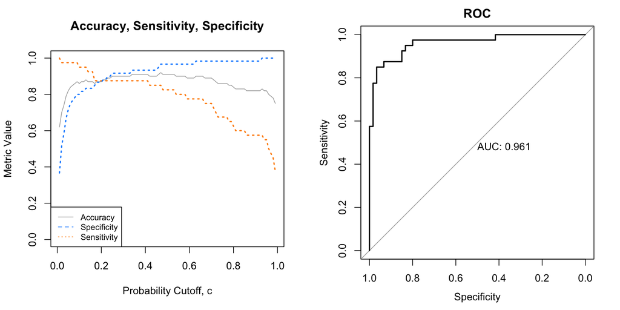

```r
par(mfrow = c(1, 2))

# custom plot
plot(c, wisc_acc, typ = "l", ylim = c(0, 1), col = "darkgrey", lwd = 1, lty = 1,
     main = "Accuracy, Sensitivity, Specificity",
     xlab = "Probability Cutoff, c", ylab = "Metric Value")
lines(c, wisc_sens, col = "darkorange", lwd = 2, lty = 3)
lines(c, wisc_spec, col = "dodgerblue", lwd = 2, lty = 3)
legend("bottomleft", c("Accuracy", "Specificity", "Sensitivity"), lty = c(1, 2, 3),
       lwd = 1, col = c("darkgrey", "dodgerblue", "darkorange"), cex = 0.8)

# ROC plot
test_roc = roc(wisc_tst$class ~ test_prob, plot = TRUE, print.auc = TRUE,
               main = "ROC")
```

# Exercise 4 (Logistic Regression Decision Boundary)

**[6 points]** Continue with the cancer data from previous exercises. Again, consider an additive logistic regression that considers *only two predictors*, `radius` and `symmetry`. Plot the test data with `radius` as the $x$ axis, and `symmetry` as the $y$ axis, with the points colored according to their tumor status. Add a line which represents the decision boundary for a classifier using 0.5 as a cutoff for predicted probability.

**Solution:**

```r
wisc_glm = glm(class ~ radius + symmetry, data = wisc_trn, family = "binomial")
```

```r
# function to calculate decision boundary for glms
glm_boundary_line = function(glm_fit) {
  intercept = as.numeric(-coef(glm_fit)[1] / coef(glm_fit)[3])
  slope = as.numeric(-coef(glm_fit)[2] / coef(glm_fit)[3])
  c(intercept = intercept, slope = slope)
}
```

[figure not shown]

```r
# function to add decision boundary for glms to an existing plot
add_glm_boundary = function(glm_fit, line_col = "black") {
  abline(glm_boundary_line(glm_fit), col = line_col, lwd = 3)
}
```

# Exercise 5 (Concept Checks)

**[1 point each]** Answer the following questions based on your results from the three exercises.

**(a)** What is $\hat{\beta}_2$ for the **multiple** model in Exercise 1?

**Solution:**

```r
coef(mod_multiple)[3]
```

```
##   origin2
## 0.1243737
```

**(b)** Based on your results in Exercise 1, which of these models performs best?

**Solution:** The **additive** model achieves the lowest test error.

**(c)** Based on your results in Exercise 1, which of these models do you think may be underfitting?

**Solution:** The **intercept**, **simple**, and **multiple** models as they all simpler than the best model, with more error.

**(d)** Based on your results in Exercise 1, which of these models do you think may be overfitting??

**Solution:** The **interaction** model as it is more complex than the best model, with more error.

**(e)** Of the classifiers in Exercise 2, which do you prefer?

**Solution:** The model with `c = 0.10`.

**(f)** State the metric you used to make your decision in part **(e)**, and a reason for using that metric.

**Solution:** The model with `c = 0.10` achieves the highest **sensitivity**, meaning it most oftens labels cancer as cancer! We value this over labeling non-cancer as non-cancer.